# AI-CA4

### K-Nearest-Neighbours

```python
knn = KNeighborsClassifier (n_neighbors = 3)
knn.fit (x_train, y_train)
```

```
KNeighborsClassifier(n_neighbors=3)
```

```python
y_pred2 = knn.predict (np.array (x_test))
```

```python
print("Accuracy:", accuracy_score(y_test, y_pred2))
```

```
Accuracy: 0.874326750448833
```

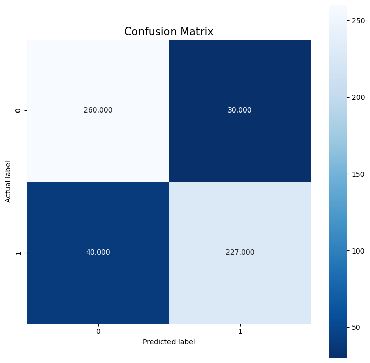

```python
cm = confusion_matrix(y_test, y_pred2)
plt.figure(figsize=(9,9))
sns.heatmap(cm, annot=True, fmt=".3f", linewidths=.5, square = True, cmap = 'Blues_r');
plt.ylabel("Actual label");
plt.xlabel("Predicted label");
all_sample_title = "Confusion Matrix"
plt.title(all_sample_title, size = 15);
```

```
Accuracy: 0.8563734290843806
```

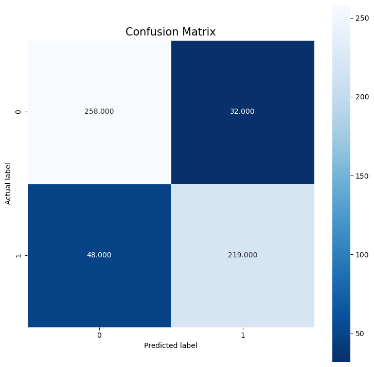

```python
knn = KNeighborsClassifier (n_neighbors = 10)
knn.fit (x_train, y_train)

y_pred2 = knn.predict (np.array (x_test))

print("Accuracy:", accuracy_score(y_test, y_pred2))

cm = confusion_matrix(y_test, y_pred2)
plt.figure(figsize=(9,9))
sns.heatmap(cm, annot=True, fmt=".3f", linewidths=.5, square = True, cmap = 'Blues_r');
plt.ylabel("Actual label");
plt.xlabel("Predicted label");
all_sample_title = "Confusion Matrix"
plt.title(all_sample_title, size = 15);
```

```python
acc = []
neighbors = list (range (1, 21))

for i in range (20):
    knn = KNeighborsClassifier (n_neighbors = neighbors[i])
    knn.fit (x_train, y_train)
    y_pred2 = knn.predict (np.array (x_test))
    acc.append (accuracy_score(y_test, y_pred2))
```

[output not shown]

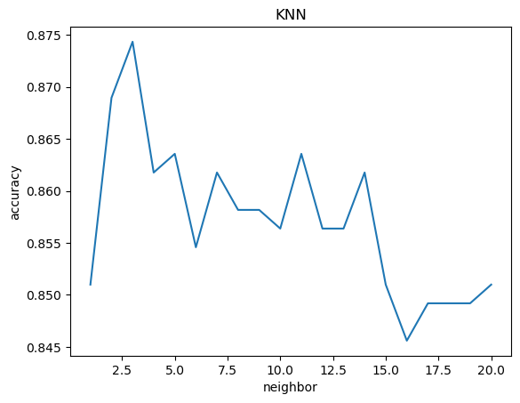

```python
plt.plot (neighbors, acc)
plt.title ("KNN")
plt.xlabel ("neighbor")
plt.ylabel ("accuracy")
plt.show ()
```

It seems we get best accuracy on 3 neighbor and increasing neighbors won't increase accuracy.

### Logistic Regression

```python
lg = LogisticRegression ()
```

```python
lg.fit (x_train, y_train)
```

```
LogisticRegression()
```

```python
y_pred3 = lg.predict (x_test)
```

```python
print("Accuracy:", accuracy_score(y_test, y_pred3))
```

```
Accuracy: 0.8833034111310593
```

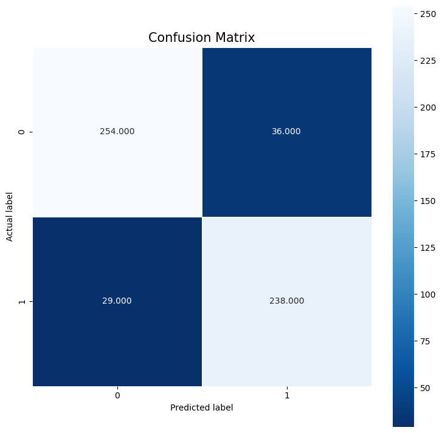

```python
cm = confusion_matrix(y_test, y_pred3)
plt.figure(figsize=(9,9))
sns.heatmap(cm, annot=True, fmt=".3f", linewidths=.5, square = True, cmap = 'Blues_r');
plt.ylabel('Actual label');
plt.xlabel('Predicted label');
all_sample_title = "Confusion Matrix"
plt.title(all_sample_title, size = 15);
```

21- Overfitting: It happens when a model do very well on training set (fit exactly on trainig set) but give low accuracy on test set. </br> Underfitting: It happens when a model too simple for fitting on training set. </br> Because we get good accuracy on test set overfitting and underfitting didn't happen.

### Random Forest

```python
clf2 = RandomForestClassifier (n_estimators = 100)
clf2.fit (x_train, y_train)
y_pred4 = clf.predict (x_test)
```

```python
print("Accuracy:", accuracy_score(y_test, y_pred4))
```

```
Accuracy: 0.9066427289048474
```

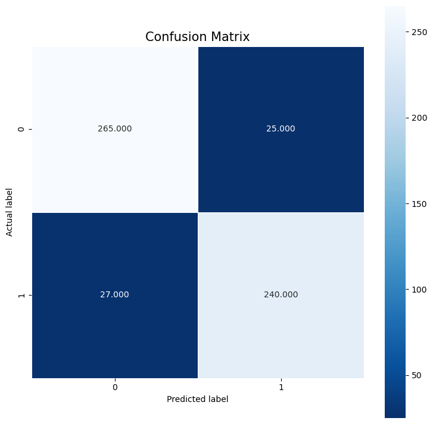

```python
cm = confusion_matrix(y_test, y_pred4)
plt.figure(figsize=(9,9))
sns.heatmap(cm, annot=True, fmt=".3f", linewidths=.5, square = True, cmap = 'Blues_r');
plt.ylabel('Actual label');
plt.xlabel('Predicted label');
all_sample_title = "Confusion Matrix"
plt.title(all_sample_title, size = 15);
```

```python
acc = []
estimators = list (range (5, 501, 5))

for i in range (100):
    clf2 = RandomForestClassifier (n_estimators = estimators[i])
    clf2.fit (x_train, y_train)
    y_pred4 = clf2.predict (x_test)
    acc.append (accuracy_score(y_test, y_pred4))
```

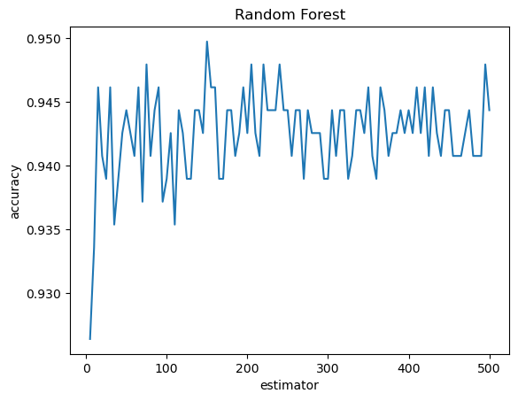

```
Best estimator: 150
```

```python
plt.plot (estimators, acc)
plt.title ("Random Forest")
plt.xlabel ("estimator")
plt.ylabel ("accuracy")
plt.show ()

print ("Best estimator:", estimators[acc.index (max (acc))])
```

24- n_estimators: It is number of tree in forest. max_depth: It is the maximum depth of a tree.

25- Bias: Bias refers to the error introduced by approximating a real-world problem with a simplified model. Shallow decision tree can have higher bias. </br> Variance: Variance refers to the model's sensitivity to fluctuations in the training dataset. Decision tree with significant depth can have higher variance. </br> In general, random forest has lower bias and lower variance than decision tree and has better accuracy. Here because problem is simple we get alomst equal accuracy.

26- It can hide real data and values so other persons can find real values and privacy is protected.

27- Laplace noise is generated from a Laplace distribution, which has a sharper peak and heavier tails that allowing for more outliers or extreme values than gaussian.

## Adding noise

```python
noise1 = np.random.normal (0, 0.1, x_train.shape)
x_train2 = x_train + noise1
noise2 = np.random.normal (0, 0.1, x_test.shape)
x_test2 = x_test + noise2
```

### Decision Tree with noise

```python
clf = tree.DecisionTreeClassifier (max_depth = 3, random_state=0)
clf.fit (x_train2, y_train)

y_pred1 = clf.predict(x_test2)
print("Accuracy:", accuracy_score(y_test, y_pred1))

cm = confusion_matrix(y_test, y_pred1)
plt.figure(figsize=(9,9))
sns.heatmap(cm, annot=True, fmt=".3f", linewidths=.5, square = True, cmap = 'Blues_r');
plt.ylabel("Actual label");
plt.xlabel("Predicted label");
all_sample_title = "Confusion Matrix"
plt.title(all_sample_title, size = 15);
```

[output not shown]

```
Accuracy: 0.9174147217235189
```

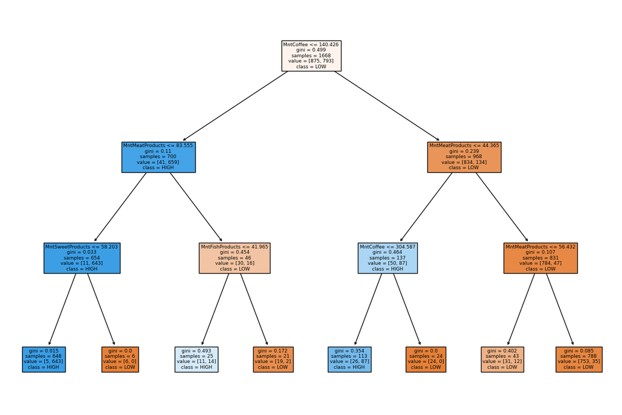

```python
fig = plt.figure(figsize=(15,10))
_ = tree.plot_tree(clf, feature_names=list(feature_names), class_names=["LOW", "HIGH"], filled=True)
```

### K-Nearest-Neighbours with noise

```
Accuracy: 0.8635547576301615
```

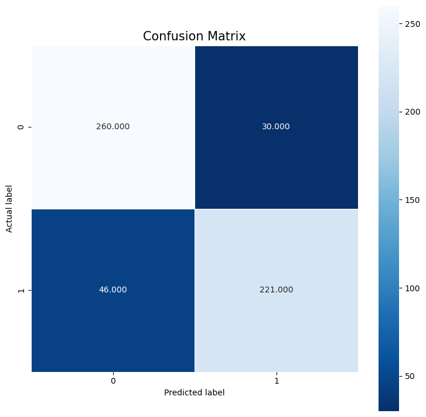

```python
knn = KNeighborsClassifier (n_neighbors = 5)
knn.fit (x_train2, y_train)
y_pred2 = knn.predict (np.array (x_test2))

print("Accuracy:", accuracy_score(y_test, y_pred2))

cm = confusion_matrix(y_test, y_pred2)
plt.figure(figsize=(9,9))
sns.heatmap(cm, annot=True, fmt=".3f", linewidths=.5, square = True, cmap = 'Blues_r');
plt.ylabel("Actual label");
plt.xlabel("Predicted label");
all_sample_title = "Confusion Matrix"
plt.title(all_sample_title, size = 15);
```

### Logistic Regression with noise

```
Accuracy: 0.8833034111310593
```

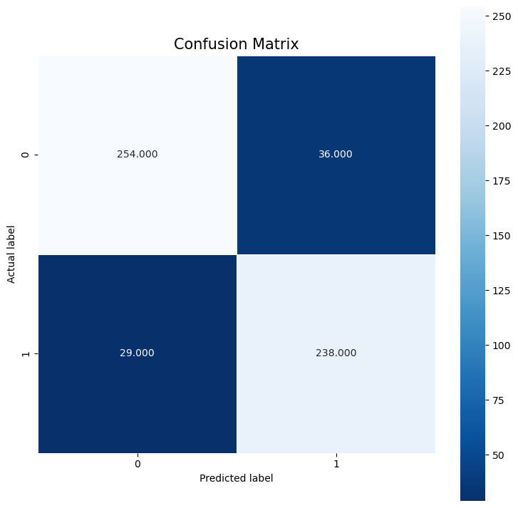

```python
lg = LogisticRegression ()
lg.fit (x_train2, y_train)
y_pred3 = lg.predict (x_test2)

print("Accuracy:", accuracy_score(y_test, y_pred3))

cm = confusion_matrix(y_test, y_pred3)
plt.figure(figsize=(9,9))
sns.heatmap(cm, annot=True, fmt=".3f", linewidths=.5, square = True, cmap = 'Blues_r');
plt.ylabel('Actual label');
plt.xlabel('Predicted label');
all_sample_title = "Confusion Matrix"
plt.title(all_sample_title, size = 15);
```

### Random Forest with noise

```python
clf2 = RandomForestClassifier (n_estimators = 100)
clf2.fit (x_train2, y_train)
y_pred4 = clf.predict (x_test2)

print("Accuracy:", accuracy_score(y_test, y_pred4))

cm = confusion_matrix(y_test, y_pred4)
plt.figure(figsize=(9,9))
sns.heatmap(cm, annot=True, fmt=".3f", linewidths=.5, square = True, cmap = 'Blues_r');
plt.ylabel('Actual label');
plt.xlabel('Predicted label');
all_sample_title = "Confusion Matrix"
plt.title(all_sample_title, size = 15);
```

[output not shown]

```
Accuracy: 0.9174147217235189
```

```python
clf2 = RandomForestClassifier (n_estimators = 200)
clf2.fit (x_train2, y_train)
y_pred4 = clf.predict (x_test2)

print("Accuracy:", accuracy_score(y_test, y_pred4))

cm = confusion_matrix(y_test, y_pred4)
plt.figure(figsize=(9,9))
sns.heatmap(cm, annot=True, fmt=".3f", linewidths=.5, square = True, cmap = 'Blues_r');
plt.ylabel('Actual label');
plt.xlabel('Predicted label');
all_sample_title = "Confusion Matrix"
plt.title(all_sample_title, size = 15);
```

[output not shown]

```
Accuracy: 0.9174147217235189
```

It seems adding noise doesn't much effect on accuracy because noise wa added to all information.

### Gradient-Boosting

```python
y_train2 = y_train.replace ({"LOW" : 0, "HIGH" : 1})
y_test2 = y_test.replace ({"LOW" : 0, "HIGH" : 1})
```

```python
model = XGBClassifier ()
model.fit (x_train, y_train2)
y_pred5 = model.predict (x_test)
```

```python
print("Accuracy:", accuracy_score(y_test2, y_pred5))
```

```
Accuracy: 0.9461400359066428
```

29- Gradient Boosting is an ensemble machine learning technique. It builds a strong predictive model by sequentially adding weak learners (usually decision trees) and improving upon their limitations. Decision tree is a single model but boosting tree is an ensemble method. Decision tree are built independently but boosting tree iteratively builds models. Decision tree is more likely to overfit.

30- XGBoost is an ensemble learning algorithm based on the principles of gradient boosting. It works by sequentially building an ensemble of weak decision tree learners to create a robust predictive model.